# CAAS Post-Processing and Declustering Analysis

PhyloPhere Pipeline

2026-02-06

```r
#  ██████╗ ██╗  ██╗██╗   ██╗██╗      ██████╗ ██████╗ ██╗  ██╗███████╗██████╗ ███████╗
#  ██╔══██╗██║  ██║╚██╗ ██╔╝██║     ██╔═══██╗██╔══██╗██║  ██║██╔════╝██╔══██╗██╔════╝
#  ██████╔╝███████║ ╚████╔╝ ██║     ██║   ██║██████╔╝███████║█████╗  ██████╔╝█████╗
#  ██╔═══╝ ██╔══██║  ╚██╔╝  ██║     ██║   ██║██╔═══╝ ██╔══██║██╔══╝  ██╔══██╗██╔══╝
#  ██║     ██║  ██║   ██║   ███████╗╚██████╔╝██║     ██║  ██║███████╗██║  ██║███████╗
#  ╚═╝     ╚═╝  ╚═╝   ╚═╝   ╚══════╝ ╚═════╝ ╚═╝     ╚═╝  ╚═╝╚══════╝╚═╝  ╚═╝╚══════╝

## PHYLOPHERE: A Nextflow pipeline including a complete set
## of phylogenetic comparative tools and analyses for Phenome-Genome studies

### Github: https://github.com/nozerorma/caastools/nf-phylophere
### Author: Miguel Ramon (miguel.ramon@upf.edu)

#### File: CAAS_postproc.Rmd
```

# 1 CAAS Post-Processing and Declustering Analysis

This script processes CAAS (Context-Aware Amino Acid Substitutions) discovery results to identify and remove false positives caused by high-density position clusters (“trains”) and statistical outliers. The workflow includes outlier detection, cluster filtering analysis, and generation of summary statistics for downstream analysis.

## 1.1 Setup and Directory Configuration

This section configures the working environment, sets directories, and loads necessary functions and libraries.

```r
# ----------------------------------------
# R Markdown Setup
# ----------------------------------------

seed_val <- 12345  # For reproducibility

# Create a directory if it doesn't exist
createDir <- function(directory) {
  if (!file.exists(directory)) {
    dir.create(directory, recursive = TRUE)
    print(sprintf("createDir: created %s", directory))
  } else {
    print(sprintf("createDir: exists %s", directory))
  }
}

setup_rmd <- function() {
  knitr::opts_chunk$set(warning = FALSE, message = FALSE)
  knitr::opts_knit$set(root.dir =getwd()) # Set working directory to project root
  set.seed(as.integer(seed_val))
}
# Define working and results directories
workingDir <- getwd()
setup_rmd()

# Load additional libraries
library(stringr)
library(purrr)
library(tibble)
library(patchwork)
library(scales)
library(ggplot2)
library(forcats)
library(ggvenn)
library(knitr)
library(kableExtra)
library(paletteer)
library(tidyverse)

# Parse command line arguments
args <- commandArgs(trailingOnly = TRUE)
if (length(args) >= 10) {
  discovery_file <- args[1]
  filter_summary_file <- args[2]
  gene_ensembl_file <- args[3]
  processing_mode <- args[4]  # "exploratory" or "filter"
  resultsDir <- args[5]
  extreme_threshold <- as.numeric(args[6])
  iqr_multiplier <- as.numeric(args[7])
  gene_filter_mode <- args[8]  # "none", "extreme", "dubious", "both"
  generate_manhattan <- as.logical(args[9])
  manhattan_min_density <- as.numeric(args[10])
} else if (length(args) >= 3) {
  # Backward compatibility - minimal args
  discovery_file <- args[1]
  filter_summary_file <- args[2]
  gene_ensembl_file <- args[3]
  processing_mode <- "exploratory"
  resultsDir <- file.path(getwd(), "caas_postproc")
  extreme_threshold <- 0.99
  iqr_multiplier <- 3.0
  gene_filter_mode <- "both"
  generate_manhattan <- TRUE
  manhattan_min_density <- 0.008
} else {
  stop("Usage: Rscript CAAS_postproc.Rmd <discovery> <filter_summary> <gene_ensembl> [mode] [outdir] [extreme_thresh] [iqr_mult] [gene_filter] [gen_manhattan] [manhattan_min_dens]")
}

# Validate input files
stopifnot(file.exists(discovery_file),
          file.exists(filter_summary_file),
          file.exists(gene_ensembl_file))

cat("=== CAAS Post-Processing Configuration ===\n")
```

```
## === CAAS Post-Processing Configuration ===
```

```r
cat("Processing mode:", processing_mode, "\n")
```

```
## Processing mode: exploratory
```

```r
cat("Gene filtering:", gene_filter_mode, "\n")
```

```
## Gene filtering: both
```

```r
cat("Extreme threshold:", extreme_threshold, paste0("(top ", 100*(1-extreme_threshold), "%)"), "\n")
```

```
## Extreme threshold: 0.99 (top 1%)
```

```r
cat("IQR multiplier:", iqr_multiplier, "\n")
```

```
## IQR multiplier: 3
```

```r
cat("Generate Manhattan plots:", generate_manhattan, "\n")
```

```
## Generate Manhattan plots: TRUE
```

```r
if (generate_manhattan) {
  cat("Manhattan min density:", manhattan_min_density, "\n")
}
```

```
## Manhattan min density: 0.008
```

```r
cat("\nInput files:\n")
```

```
##
## Input files:
```

```r
cat("  Discovery:", discovery_file, "\n")
```

```
##   Discovery: discovery.tab
```

```r
cat("  Filter summary:", filter_summary_file, "\n")
```

```
##   Filter summary: discarded_summary.tsv
```

```r
cat("  Gene ensembl:", gene_ensembl_file, "\n\n")
```

```
##   Gene ensembl: ensembl_genes.output
```

```r
# Define output directories from passed parameter
caas_postproc_dir <- resultsDir
outliers_dir <- file.path(caas_postproc_dir, "outliers")
cluster_dir <- file.path(caas_postproc_dir, "clusters")

createDir(caas_postproc_dir)
```

```
## [1] "createDir: created Out/integrated_test/neoplasia_prevalence_toy/20260206_131915/postprocessing/exploratory"
```

```r
createDir(outliers_dir)
```

```
## [1] "createDir: created Out/integrated_test/neoplasia_prevalence_toy/20260206_131915/postprocessing/exploratory/outliers"
```

```r
createDir(cluster_dir)
```

```
## [1] "createDir: created Out/integrated_test/neoplasia_prevalence_toy/20260206_131915/postprocessing/exploratory/clusters"
```

```r
# Consistent colorblind-friendly palette
category_palette <- c(
  Extreme = "#E41A1C",
  Dubious = "#377EB8",
  Both = "#984EA3",
  Normal = "#4DAF4A"
)

removal_palette <- c(
  Discarded = "#D62728",
  Good = "#2CA02C"
)
```

## 1.2 1. Data Loading and Gene Length Annotation

This section loads CAAS discovery results and annotates genes with their alignment lengths.

```r
# Load CAAS discovery file
cat("Loading CAAS discovery results...\n")
```

```
## Loading CAAS discovery results...
```

```r
# Here we load the discovery, either from the pipeline or from a discovery file generated previously

# Read discovery file (tab-separated, expects Gene and Position columns)
discovery_df <- read_tsv(discovery_file, show_col_types = FALSE)

cat("  Loaded CAAS positions:", nrow(discovery_df), "\n")
```

```
##   Loaded CAAS positions: 742
```

```r
cat("  Unique genes:", n_distinct(discovery_df$Gene), "\n")
```

```
##   Unique genes: 63
```

```r
# Load gene lengths (no header: Gene ↔ Length)
cat("Loading gene length annotations...\n")
```

```
## Loading gene length annotations...
```

```r
# Read gene ensembl file (format: gene, chr, start, end, strand, length)
gene_ensembl <- read_tsv(gene_ensembl_file, show_col_types = FALSE)

# Normalize column names to lowercase
names(gene_ensembl) <- tolower(names(gene_ensembl))

# Validate required columns
if (!"gene" %in% names(gene_ensembl) || !"length" %in% names(gene_ensembl)) {
  stop("Gene ensembl file must have 'gene' and 'length' columns")
}

# Extract Gene and Length for backwards compatibility
gene_length <- gene_ensembl %>%
  select(Gene = gene, Length = length)

cat("  Gene length records:", nrow(gene_length), "\n")
```

```
##   Gene length records: 15837
```

```r
# Annotate CAAS with gene lengths
discovery_df <- discovery_df %>%
  left_join(gene_length, by = "Gene") %>%
  filter(!is.na(Length))  # Remove genes without length info

cat("  Genes with length annotation:", n_distinct(discovery_df$Gene), "\n\n")
```

```
##   Genes with length annotation: 62
```

## 1.3 2. Outlier Gene Detection

This section identifies genes with unusually high CAAS counts using two complementary methods:

- **Extreme genes**: Top percentile by CAAS density (positions per gene length)
- **Dubious genes**: IQR outliers (Tukey’s fences at k×IQR)

Note: Actual gene removal is performed by filter_caas_genes.py module. This section visualizes thresholds.

```r
# Summarize CAAS counts and density by gene
gene_summary <- discovery_df %>%
  group_by(Gene) %>%
  summarise(
    n_CAAS = n(),
    Length = first(Length),
    n_CAAS_per_length = n() / first(Length),
    .groups = 'drop'
  )

# Calculate IQR-based extreme outlier thresholds (k×IQR from config)
Q1 <- quantile(gene_summary$n_CAAS, 0.25, na.rm = TRUE)
Q3 <- quantile(gene_summary$n_CAAS, 0.75, na.rm = TRUE)
IQR_val <- Q3 - Q1
threshold_dubious <- Q3 + iqr_multiplier * IQR_val

# Calculate top percentile threshold by CAAS density (from config)
threshold_extreme <- quantile(gene_summary$n_CAAS_per_length, extreme_threshold, na.rm = TRUE)

# Annotate genes as Extreme and/or Dubious
gene_summary_annotated <- gene_summary %>%
  mutate(
    Extreme = n_CAAS_per_length >= threshold_extreme,
    Dubious = n_CAAS >= threshold_dubious,
    Category = case_when(
      Extreme & Dubious ~ "Both",
      Extreme ~ "Extreme",
      Dubious ~ "Dubious",
      TRUE ~ "Normal"
    )
  ) %>%
  arrange(desc(n_CAAS))

# CAAS count distribution plot
p_caas_dist <- ggplot(gene_summary_annotated, aes(x = n_CAAS, fill = Category)) +
  geom_histogram(binwidth = 5, alpha = 0.7, color = "black") +
  scale_fill_manual(values = category_palette) +
  labs(title = "CAAS Count Distribution by Gene",
       subtitle = "Outliers identified by density (Extreme) and IQR (Dubious)",
       x = "Number of CAAS Positions",
       y = "Gene Count") +
  theme_minimal() +
  theme(legend.position = "right",
        plot.title = element_text(face = "bold", size = 14),
        axis.title = element_text(size = 12))

# CAAS density distribution plot
p_density_dist <- ggplot(gene_summary_annotated, aes(x = n_CAAS_per_length, fill = Category)) +
  geom_histogram(bins = 50, alpha = 0.7, color = "black") +
  scale_fill_manual(values = category_palette) +
  geom_vline(xintercept = threshold_extreme, linetype = "dashed", color = "#E41A1C", size = 1) +
  labs(title = "CAAS Density Distribution",
       subtitle = "Top 1% density threshold shown as dashed line",
       x = "CAAS Density (positions / gene length)",
       y = "Gene Count") +
  theme_minimal() +
  theme(legend.position = "right",
        plot.title = element_text(face = "bold", size = 14),
        axis.title = element_text(size = 12))

# Combined plot
combined_outlier_plot <- p_caas_dist / p_density_dist

print(combined_outlier_plot)
```

[figure not shown]

```r
ggsave(
  file.path(outliers_dir, "outlier_distributions.png"),
  combined_outlier_plot,
  width = 12, height = 10, dpi = 320
)

# Summary statistics
cat("\n=== Outlier Detection Summary ===\n")
```

```
##
## === Outlier Detection Summary ===
```

```r
cat("Thresholds:\n")
```

```
## Thresholds:
```

```r
cat("  Extreme (top 1% density):", sprintf("%.4f", threshold_extreme), "\n")
```

```
##   Extreme (top 1% density): 0.1074
```

```r
cat("  Dubious (Q3 + 3×IQR):", threshold_dubious, "positions\n\n")
```

```
##   Dubious (Q3 + 3×IQR): 57 positions
```

```r
outlier_counts <- gene_summary_annotated %>%
  count(Category) %>%
  mutate(Percent = sprintf("%.1f%%", 100 * n / sum(n)))

print(outlier_counts)
```

```
## # A tibble: 3 × 3
##   Category     n Percent
##   <chr>    <int> <chr>
## 1 Dubious      2 3.2%
## 2 Extreme      1 1.6%
## 3 Normal      59 95.2%
```

```r
# Export gene summary
write_tsv(
  gene_summary_annotated,
  file.path(outliers_dir, "gene_summary_annotated.tsv")
)

cat("\n✓ Gene summary exported\n\n")
```

```
##
## ✓ Gene summary exported
```

## 1.4 3. Cluster Filtering Analysis

This section analyzes the cluster filtering results from the parameter sweep or single filter run.

This should be dependent on whether we have launched the tool in “explore” or “filter” mode

```r
# Load filter summary
cat("Loading cluster filter summary...\n")
```

```
## Loading cluster filter summary...
```

```r
filter_summary <- read_tsv(filter_summary_file, show_col_types = FALSE)

cat("  Parameter combinations tested:", nrow(filter_summary), "\n\n")
```

```
##   Parameter combinations tested: 9
```

```r
# Display summary table
kable(filter_summary,
      caption = "Cluster Filtering Parameter Sweep Results",
      align = c("l", "r", "r", "r")) %>%
  kable_styling(bootstrap_options = c("striped", "hover", "condensed"))
```

Cluster Filtering Parameter Sweep Results

| File | DiscardedCount | Minlen | Maxcaas |
| --- | --- | --- | --- |
| discovery.filtered.minlen2.maxcaas60 | 37 | 2 | 60 |
| discovery.filtered.minlen2.maxcaas70 | 29 | 2 | 70 |
| discovery.filtered.minlen2.maxcaas80 | 29 | 2 | 80 |
| discovery.filtered.minlen3.maxcaas60 | 5 | 3 | 60 |
| discovery.filtered.minlen3.maxcaas70 | 0 | 3 | 70 |
| discovery.filtered.minlen3.maxcaas80 | 0 | 3 | 80 |
| discovery.filtered.minlen4.maxcaas60 | 0 | 4 | 60 |
| discovery.filtered.minlen4.maxcaas70 | 0 | 4 | 70 |
| discovery.filtered.minlen4.maxcaas80 | 0 | 4 | 80 |

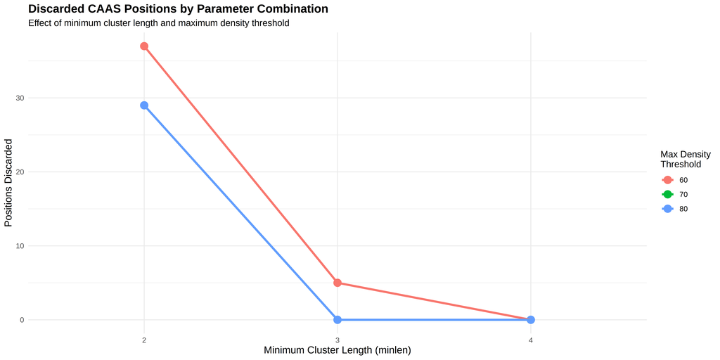

```r
# Plot parameter sweep results (if multiple combinations)
if (nrow(filter_summary) > 1) {
  p_param_sweep <- ggplot(filter_summary,
                          aes(x = factor(Minlen),
                              y = DiscardedCount,
                              color = factor(Maxcaas),
                              group = factor(Maxcaas))) +
    geom_point(size = 4) +
    geom_line(size = 1.2) +
    labs(title = "Discarded CAAS Positions by Parameter Combination",
         subtitle = "Effect of minimum cluster length and maximum density threshold",
         x = "Minimum Cluster Length (minlen)",
         y = "Positions Discarded",
         color = "Max Density\nThreshold") +
    theme_minimal() +
    theme(legend.position = "right",
          plot.title = element_text(face = "bold", size = 14),
          axis.title = element_text(size = 12))

  print(p_param_sweep)

  ggsave(
    file.path(cluster_dir, "parameter_sweep.png"),
    p_param_sweep,
    width = 12, height = 6, dpi = 320
  )
}
```

```r
# Export filter summary
write_tsv(
  filter_summary,
  file.path(cluster_dir, "filter_summary.tsv")
)

cat("✓ Filter summary exported\n\n")
```

```
## ✓ Filter summary exported
```

## 1.5 4. Genomic Distribution Visualization (Manhattan Plot)

This section visualizes CAAS density across the genome if genomic coordinates are available and Manhattan plotting is enabled.

```r
# Check if gene_ensembl data has chromosome information
if (!"chr" %in% names(gene_ensembl)) {
  cat("⚠ Chromosome information not available in gene ensembl file, skipping Manhattan plot\n")
} else {
  cat("Preparing Manhattan plot data...\n")

  # Use the gene_ensembl data that's already loaded (has: gene, chr, start, end, strand, length)
  genomic_info <- gene_ensembl

  # Helper functions for chromosome layout
  compute_chr_layout <- function(df) {
    layout_df <- df %>%
      mutate(chr_num = str_replace(chr, "chr", "")) %>%
      mutate(chr_rank = case_when(
        chr_num %in% as.character(1:22) ~ as.numeric(chr_num),
        chr_num == "X" ~ 23,
        chr_num == "Y" ~ 24,
        chr_num %in% c("M", "MT") ~ 25,
        TRUE ~ 26
      )) %>%
      group_by(chr_num, chr_rank) %>%
      summarise(chr_max = max(pos, na.rm = TRUE), .groups = "drop") %>%
      arrange(chr_rank) %>%
      mutate(
        chr_start = lag(cumsum(chr_max), default = 0),
        chr_center = chr_start + chr_max / 2
      )
    layout_df %>% mutate(chr_order = chr_rank)
  }

  apply_chr_layout <- function(df, layout_df) {
    df %>%
      mutate(chr_num = str_replace(chr, "chr", "")) %>%
      left_join(layout_df %>% select(chr_num, chr_start), by = "chr_num") %>%
      mutate(BPcum = pos + chr_start)
  }

  # Prepare Manhattan plot data
  manhattan_data <- gene_summary_annotated %>%
    left_join(genomic_info %>% select(gene, chr, start, end),
              by = c("Gene" = "gene")) %>%
    filter(!is.na(chr)) %>%
    mutate(
      chr_num = str_replace(chr, "chr", ""),
      chr_order = case_when(
        chr_num %in% as.character(1:22) ~ as.numeric(chr_num),
        chr_num == "X" ~ 23,
        chr_num == "Y" ~ 24,
        chr_num == "M" ~ 25,
        TRUE ~ 26
      ),
      pos = (start + end) / 2,
      plot_density = case_when(
        is.na(n_CAAS_per_length) ~ NA_real_,
        n_CAAS_per_length <= 0 ~ manhattan_min_density,
        TRUE ~ n_CAAS_per_length
      )
    ) %>%
    arrange(chr_order, pos)

  if (nrow(manhattan_data) == 0) {
    cat("⚠ No genes with genomic coordinates found\n")
  } else {
    # Calculate chromosome layout
    chr_lengths <- manhattan_data %>%
      select(chr, pos) %>%
      compute_chr_layout()

    # Add cumulative positions
    manhattan_data <- apply_chr_layout(manhattan_data, chr_lengths)

    # Axis data for chromosome labels
    axis_data <- chr_lengths %>%
      select(chr_num, chr_center) %>%
      rename(center = chr_center)

    # Create Manhattan plot
    p_manhattan <- ggplot(manhattan_data, aes(x = BPcum, y = plot_density, color = Category)) +
      geom_vline(
        data = chr_lengths %>% filter(chr_order > 1),
        aes(xintercept = chr_start),
        color = "gray20",
        linetype = "dashed",
        linewidth = 0.3,
        alpha = 0.6
      ) +
      geom_point(
        data = manhattan_data %>% filter(Category == "Normal"),
        alpha = 0.35, size = 1.5
      ) +
      geom_point(
        data = manhattan_data %>% filter(Category == "Dubious"),
        alpha = 0.8, size = 2.5
      ) +
      geom_point(
        data = manhattan_data %>% filter(Category == "Extreme"),
        alpha = 0.8, size = 2.5
      ) +
      geom_point(
        data = manhattan_data %>% filter(Category == "Both"),
        alpha = 1, size = 3, shape = 17
      ) +
      scale_color_manual(
        values = category_palette,
        drop = FALSE
      ) +
      scale_x_continuous(
        label = axis_data$chr_num,
        breaks = axis_data$center,
        expand = expansion(mult = c(0.005, 0.005))
      ) +
      scale_y_log10(
        breaks = c(0.01, 0.05, 0.1, 0.5, 1, 2, 5, 10, 20, 50),
        labels = c("0.01", "0.05", "0.1", "0.5", "1", "2", "5", "10", "20", "50")
      ) +
      labs(
        title = paste0("Genomic Distribution of CAAS Density (", processing_mode, " mode)"),
        subtitle = paste0("Gene filtering: ", gene_filter_mode,
                         " | Extreme threshold: top ", 100*(1-extreme_threshold), "%",
                         " | IQR multiplier: ", iqr_multiplier, "×"),
        x = "Chromosome",
        y = "CAAS per Gene Length (%, log scale)",
        color = "Gene Category",
        caption = paste0(
          "Extreme genes (top percentile density) and Dubious genes (IQR outliers) ",
          "are flagged for potential removal. Genes in 'Both' category are flagged by both criteria."
        )
      ) +
      theme_minimal(base_size = 11) +
      theme(
        axis.text.x = element_text(angle = 0, hjust = 0.5, size = 9),
        panel.grid.major.x = element_blank(),
        panel.grid.minor.x = element_blank(),
        legend.position = "top",
        legend.box = "horizontal",
        axis.title.x = element_text(margin = margin(t = 10)),
        axis.title.y = element_text(margin = margin(r = 10))
      )

    print(p_manhattan)

    ggsave(
      filename = file.path(outliers_dir, "manhattan_plot.png"),
      plot = p_manhattan,
      width = 16,
      height = 8,
      dpi = 320,
      dev = "png"
    )

    cat("✓ Manhattan plot generated\n\n")
  }
}
```

```
## Preparing Manhattan plot data...
```

[figure not shown]

```
## ✓ Manhattan plot generated
```

## 1.6 5. Impact Summary

This section provides overall statistics on the post-processing analysis.

```r
cat("\n=== CAAS Post-Processing Impact Summary ===\n\n")
```

```
##
## === CAAS Post-Processing Impact Summary ===
```

```r
# Gene statistics
cat("Gene-level statistics:\n")
```

```
## Gene-level statistics:
```

```r
cat("  Total genes analyzed:", n_distinct(discovery_df$Gene), "\n")
```

```
##   Total genes analyzed: 62
```

```r
cat("  Extreme genes (top 1% density):", sum(gene_summary_annotated$Extreme), "\n")
```

```
##   Extreme genes (top 1% density): 1
```

```r
cat("  Dubious genes (IQR outliers):", sum(gene_summary_annotated$Dubious), "\n")
```

```
##   Dubious genes (IQR outliers): 2
```

```r
cat("  Both categories:", sum(gene_summary_annotated$Extreme & gene_summary_annotated$Dubious), "\n")
```

```
##   Both categories: 0
```

```r
cat("  Normal genes:", sum(gene_summary_annotated$Category == "Normal"), "\n\n")
```

```
##   Normal genes: 59
```

```r
# Position statistics
cat("Position-level statistics:\n")
```

```
## Position-level statistics:
```

```r
cat("  Total CAAS positions:", nrow(discovery_df), "\n")
```

```
##   Total CAAS positions: 733
```

```r
if (nrow(filter_summary) > 0) {
  cat("  Positions flagged by filtering:\n")
  for (i in 1:nrow(filter_summary)) {
    cat(sprintf("    minlen=%d, maxcaas=%.2f: %d positions\n",
                filter_summary$Minlen[i],
                filter_summary$Maxcaas[i],
                filter_summary$DiscardedCount[i]))
  }
}
```

```
##   Positions flagged by filtering:
##     minlen=2, maxcaas=60.00: 37 positions
##     minlen=2, maxcaas=70.00: 29 positions
##     minlen=2, maxcaas=80.00: 29 positions
##     minlen=3, maxcaas=60.00: 5 positions
##     minlen=3, maxcaas=70.00: 0 positions
##     minlen=3, maxcaas=80.00: 0 positions
##     minlen=4, maxcaas=60.00: 0 positions
##     minlen=4, maxcaas=70.00: 0 positions
##     minlen=4, maxcaas=80.00: 0 positions
```

```r
# Create summary table for export
summary_table <- tibble(
  Metric = c(
    "Total CAAS Positions",
    "Unique Genes",
    "Extreme Genes (top 1% density)",
    "Dubious Genes (IQR outliers)",
    "Both Extreme and Dubious",
    "Normal Genes",
    "Extreme Threshold (density)",
    "Dubious Threshold (count)"
  ),
  Value = c(
    nrow(discovery_df),
    n_distinct(discovery_df$Gene),
    sum(gene_summary_annotated$Extreme),
    sum(gene_summary_annotated$Dubious),
    sum(gene_summary_annotated$Extreme & gene_summary_annotated$Dubious),
    sum(gene_summary_annotated$Category == "Normal"),
    sprintf("%.4f", threshold_extreme),
    as.character(threshold_dubious)
  )
)

kable(summary_table,
      caption = "CAAS Post-Processing Summary Statistics",
      align = c("l", "r")) %>%
  kable_styling(bootstrap_options = c("striped", "hover"))
```

CAAS Post-Processing Summary Statistics

| Metric | Value |
| --- | --- |
| Total CAAS Positions | 733 |
| Unique Genes | 62 |
| Extreme Genes (top 1% density) | 1 |
| Dubious Genes (IQR outliers) | 2 |
| Both Extreme and Dubious | 0 |
| Normal Genes | 59 |
| Extreme Threshold (density) | 0.1074 |
| Dubious Threshold (count) | 57 |

```r
# Export summary
write_tsv(
  summary_table,
  file.path(caas_postproc_dir, "summary_statistics.tsv")
)

cat("\n✓ Summary statistics exported\n")
```

```
##
## ✓ Summary statistics exported
```

```r
cat("\n=== Analysis Complete ===\n")
```

```
##
## === Analysis Complete ===
```